# R Bridge - Final Project

Leland Randles

August 7, 2016

## Data Transformation and Exploratory Analysis Using ‘hflights’ Package

- Citation information and documentation for the ‘hflights’ package can be found here: https://cran.r-project.org/web/packages/hflights/hflights.pdf
- The package consists of a single dataset called ‘hflights’

### Outline

- Load “hflights” package
- Preparatory Data Profiling
- Selection of Variables for Analysis
- Create Data Frames for Analysis and Graphics
- Display and Comment on Graphics

#### Load “hflights” package

```r
install.packages("hflights", repos='https://mirrors.nics.utk.edu/cran/')
library(hflights)
```

Visually inspect data:

```r
head(hflights)
```

```
##      Year Month DayofMonth DayOfWeek DepTime ArrTime UniqueCarrier
## 5424 2011     1          1         6    1400    1500            AA
## 5425 2011     1          2         7    1401    1501            AA
## 5426 2011     1          3         1    1352    1502            AA
## 5427 2011     1          4         2    1403    1513            AA
## 5428 2011     1          5         3    1405    1507            AA
## 5429 2011     1          6         4    1359    1503            AA
##      FlightNum TailNum ActualElapsedTime AirTime ArrDelay DepDelay Origin
## 5424       428  N576AA                60      40      -10        0    IAH
## 5425       428  N557AA                60      45       -9        1    IAH
## 5426       428  N541AA                70      48       -8       -8    IAH
## 5427       428  N403AA                70      39        3        3    IAH
## 5428       428  N492AA                62      44       -3        5    IAH
## 5429       428  N262AA                64      45       -7       -1    IAH
##      Dest Distance TaxiIn TaxiOut Cancelled CancellationCode Diverted
## 5424  DFW      224      7      13         0                         0
## 5425  DFW      224      6       9         0                         0
## 5426  DFW      224      5      17         0                         0
## 5427  DFW      224      9      22         0                         0
## 5428  DFW      224      9       9         0                         0
## 5429  DFW      224      6      13         0                         0
```

#### Preparatory Data Profiling

I started by glancing at the structure of the dataset to supplement the documentation (i.e., seeing how the Year, Month and Day columns are poplated) as well as to verify the number of observations:

```r
str(hflights)
```

```
## 'data.frame':    227496 obs. of  21 variables:
##  $ Year             : int  2011 2011 2011 2011 2011 2011 2011 2011 2011 2011 ...
##  $ Month            : int  1 1 1 1 1 1 1 1 1 1 ...
##  $ DayofMonth       : int  1 2 3 4 5 6 7 8 9 10 ...
##  $ DayOfWeek        : int  6 7 1 2 3 4 5 6 7 1 ...
##  $ DepTime          : int  1400 1401 1352 1403 1405 1359 1359 1355 1443 1443 ...
##  $ ArrTime          : int  1500 1501 1502 1513 1507 1503 1509 1454 1554 1553 ...
##  $ UniqueCarrier    : chr  "AA" "AA" "AA" "AA" ...
##  $ FlightNum        : int  428 428 428 428 428 428 428 428 428 428 ...
##  $ TailNum          : chr  "N576AA" "N557AA" "N541AA" "N403AA" ...
##  $ ActualElapsedTime: int  60 60 70 70 62 64 70 59 71 70 ...
##  $ AirTime          : int  40 45 48 39 44 45 43 40 41 45 ...
##  $ ArrDelay         : int  -10 -9 -8 3 -3 -7 -1 -16 44 43 ...
##  $ DepDelay         : int  0 1 -8 3 5 -1 -1 -5 43 43 ...
##  $ Origin           : chr  "IAH" "IAH" "IAH" "IAH" ...
##  $ Dest             : chr  "DFW" "DFW" "DFW" "DFW" ...
##  $ Distance         : int  224 224 224 224 224 224 224 224 224 224 ...
##  $ TaxiIn           : int  7 6 5 9 9 6 12 7 8 6 ...
##  $ TaxiOut          : int  13 9 17 22 9 13 15 12 22 19 ...
##  $ Cancelled        : int  0 0 0 0 0 0 0 0 0 0 ...
##  $ CancellationCode : chr  "" "" "" "" ...
##  $ Diverted         : int  0 0 0 0 0 0 0 0 0 0 ...
```

Next, in an attempt to determine how I wanted to treat NA values, I used sapply to see how many NA values exist in each column:

```r
sapply(hflights, function(y) sum(length(which(is.na(y)))))
```

```
##              Year             Month        DayofMonth         DayOfWeek
##                 0                 0                 0                 0
##           DepTime           ArrTime     UniqueCarrier         FlightNum
##              2905              3066                 0                 0
##           TailNum ActualElapsedTime           AirTime          ArrDelay
##                 0              3622              3622              3622
##          DepDelay            Origin              Dest          Distance
##              2905                 0                 0                 0
##            TaxiIn           TaxiOut         Cancelled  CancellationCode
##              3066              2947                 0                 0
##          Diverted
##                 0
```

I can see that eight different columns have NA values, with the number of NA values ranging from 2,905 to 3,622. Next, I used the nrow function to see how many rows had at least one NA value:

```r
nrow(hflights[rowSums(is.na(hflights))!=0,])
```

```
## [1] 3622
```

Considering that eight different columns had NA values ranging from 2,905 to 3,622, and the number of rows which have any column with an NA value is 3,622, it is clear that when there is one column with an NA value, many or all of the other seven columns also have an NA value. Therefore, I decided to exclude rows with any NA values from my analysis (see Create Data Frames for Analysis and Graphics section).

Next, I used the unique function on multiple columns 1) to confirm my expections regarding distinct values, and 2) to ascertain which columns were practical to include in this analysis given the scope of the assignment. Examples:

```r
unique(hflights$Month)
```

```
##  [1]  1  2  3  4  5  6  7  8  9 10 11 12
```

Confirms that values range from 1 to 12.

```r
unique(hflights$DayOfWeek)
```

```
## [1] 6 7 1 2 3 4 5
```

Confirms that values range from 1 to 7 with 1 being Monday.

```r
unique(hflights$Origin)
```

```
## [1] "IAH" "HOU"
```

Confirms that IAH and HOU are the only departure Origin values.

```r
unique(hflights$Dest)
```

```
##   [1] "DFW" "MIA" "SEA" "JFK" "HNL" "MSY" "SAT" "AUS" "LAX" "DEN" "EWR"
##  [12] "ORD" "ONT" "DCA" "SFO" "LAS" "TPA" "PDX" "SJU" "PHX" "BWI" "LGA"
##  [23] "CLE" "RDU" "BOS" "IND" "SAN" "IAD" "SJC" "TUL" "MFE" "PIT" "SLC"
##  [34] "SNA" "MCO" "MSP" "EGE" "ATL" "PHL" "DTW" "FLL" "CLT" "RSW" "MCI"
##  [45] "SMF" "ELP" "OKC" "ABQ" "TUS" "PBI" "OMA" "HDN" "GUC" "MTJ" "BHM"
##  [56] "CMH" "COS" "GRR" "ASE" "MKE" "BNA" "CRP" "DAL" "ECP" "HRL" "JAN"
##  [67] "JAX" "LIT" "MAF" "MDW" "OAK" "STL" "MEM" "CVG" "SDF" "BTR" "RIC"
##  [78] "LRD" "ORF" "PNS" "CRW" "XNA" "AEX" "BRO" "DAY" "GPT" "GSO" "SAV"
##  [89] "ICT" "HSV" "AVL" "LEX" "LFT" "LCH" "LBB" "DSM" "CHS" "CAE" "GSP"
## [100] "SHV" "TYS" "MOB" "VPS" "AMA" "GRK" "RNO" "BPT" "MLU" "AGS" "BFL"
## [111] "ANC" "CID" "GJT" "BKG" "HOB" "PSP"
```

Shows that Dest has too many distinct values to include as a variable for analysis in this project, given its scope.

Lastly, I looked at the lowest and highest values for selected numeric columns (examples below) to get a feel how I could use ranges in my analyses:

```r
c(hflights$ActualElapsedTime[which.min(hflights$ActualElapsedTime)],hflights$ActualElapsedTime[which.max(hflights$ActualElapsedTime)])
```

```
## [1]  34 575
```

```r
c(hflights$Distance[which.min(hflights$Distance)],hflights$Distance[which.max(hflights$Distance)])
```

```
## [1]   79 3904
```

```r
c(hflights$ArrDelay[which.min(hflights$ArrDelay)],hflights$ArrDelay[which.max(hflights$ArrDelay)])
```

```
## [1] -70 978
```

#### Selection of Variables for Analysis

After completing the basic data profiling described in the prior section, I chose the following columns for inclusion in my analyses: Year, Month, DayofMonth, DayOfWeek, ArrDelay, Origin, and Distance.

Below are the questions I want to consider: 1. Does the percentage of flights with ArrDelay > 10 vary by month? In other words, is there a seasonal element to the percentage of delayed flights? What about DayOfWeek? 2. What’s the frequency for delayed flights by range of time delay? (Defining “delayed” to mean ArrDelay > 10). Are the airports comparable? 3. Is there a relationship between the Distance of flights and the ArrDelay (for flights where ArrDelay > 10)?

I’m using ArrDelay > 10 based on the assumption that travelers won’t be annoyed by a delay unless it is at least 10 minutes. I’m ignoring DepDelay on the assumption that travellers don’t care if their departure is delayed as long as they arrive on time, so the key factor is ArrDelay.

#### Create Data Frames for Analysis and Graphics

First, I created a data frame consisting of the rows which do not have NA values in any column.

```r
hf_excl_na <- hflights[rowSums(is.na(hflights))==0,]
```

Then, I subsetted that data frame to include only the columns I’m interested in:

```r
c <- c("Year", "Month", "DayofMonth", "DayOfWeek", "ArrDelay", "Origin", "Distance")
hf_selected_cols <- hf_excl_na[c]
```

After that, I added two columns for plotting: MonthLabel and DayOfWeekLabel:

```r
# Use of recode function requires
install.packages("car", repos='https://mirrors.nics.utk.edu/cran/')
```

```r
library(car)
# Add MonthLabel
hf_selected_cols$MonthLabel <- ifelse(nchar(hf_selected_cols$Month)==1,paste0("0",as.character(hf_selected_cols$Month)," - ",recode(as.character(hf_selected_cols$Month),"'1'='Jan';'2'='Feb';'3'='Mar';'4'='Apr';'5'='May';'6'='Jun';'7'='Jul';'8'='Aug';'9'='Sep';'10'='Oct';'11'='Nov';'12'='Dec'")),paste0(as.character(hf_selected_cols$Month)," - ",recode(as.character(hf_selected_cols$Month),"'1'='Jan';'2'='Feb';'3'='Mar';'4'='Apr';'5'='May';'6'='Jun';'7'='Jul';'8'='Aug';'9'='Sep';'10'='Oct';'11'='Nov';'12'='Dec'")))
# Add DayOfWeekLabel
hf_selected_cols$DayOfWeekLabel <- paste0(
as.character(hf_selected_cols$DayOfWeek)," - ",recode(as.character(hf_selected_cols$DayOfWeek),"'1'='Mon';'2'='Tue';'3'='Wed';'4'='Thu';'5'='Fri';'6'='Sat';'7'='Sun'"))
#Visually inspect data
head(hf_selected_cols)
```

```
##      Year Month DayofMonth DayOfWeek ArrDelay Origin Distance MonthLabel
## 5424 2011     1          1         6      -10    IAH      224   01 - Jan
## 5425 2011     1          2         7       -9    IAH      224   01 - Jan
## 5426 2011     1          3         1       -8    IAH      224   01 - Jan
## 5427 2011     1          4         2        3    IAH      224   01 - Jan
## 5428 2011     1          5         3       -3    IAH      224   01 - Jan
## 5429 2011     1          6         4       -7    IAH      224   01 - Jan
##      DayOfWeekLabel
## 5424        6 - Sat
## 5425        7 - Sun
## 5426        1 - Mon
## 5427        2 - Tue
## 5428        3 - Wed
## 5429        4 - Thu
```

Next, I added a column called ArrDelay_Range based on ranges for the ArrDelay values, and a column called ArrDelay_Over_Ten, which is 0 if the ArrDelay is less than 11 and 1 if the ArrDelay is between 11 and 290:

```r
# Function to group ArrDelay into ranges
r <- function(x) {
    if (x >= 11 & x <= 50) {"011-050"}
        else if (x >= 51 & x <= 90) {"051-090"}
          else if (x >= 91 & x <= 130) {"091-130"}
          else if (x >= 131 & x <= 170) {"131-170"}
          else if (x >= 171 & x <= 210) {"171-210"}
          else if (x >= 211 & x <= 250) {"211-250"}
          else if (x >= 251 & x <= 290) {"251-290"}
          else if (x >= 291) {"Very late"}
          else {"10 or Less"}
}
# Add and populate ArrDelay_Range column in data frame based on ArrDelay
hf_selected_cols$ArrDelay_Range <- mapply(r,hf_selected_cols$ArrDelay)
# Add ArrDelay_OverTen indicator
hf_selected_cols$ArrDelay_OverTen <- ifelse(hf_selected_cols$ArrDelay > 10 & hf_selected_cols$ArrDelay < 291,1,0)
# Visually inspect data
head(hf_selected_cols)
```

```
##      Year Month DayofMonth DayOfWeek ArrDelay Origin Distance MonthLabel
## 5424 2011     1          1         6      -10    IAH      224   01 - Jan
## 5425 2011     1          2         7       -9    IAH      224   01 - Jan
## 5426 2011     1          3         1       -8    IAH      224   01 - Jan
## 5427 2011     1          4         2        3    IAH      224   01 - Jan
## 5428 2011     1          5         3       -3    IAH      224   01 - Jan
## 5429 2011     1          6         4       -7    IAH      224   01 - Jan
##      DayOfWeekLabel ArrDelay_Range ArrDelay_OverTen
## 5424        6 - Sat     10 or Less                0
## 5425        7 - Sun     10 or Less                0
## 5426        1 - Mon     10 or Less                0
## 5427        2 - Tue     10 or Less                0
## 5428        3 - Wed     10 or Less                0
## 5429        4 - Thu     10 or Less                0
```

I then built my final datasets for the graphics. To create some of the datasets, I needed the sqldf package.

Citiation information for sqldf: G. Grothendieck (2014). sqldf: Perform SQL Selects on R Data Frames. R package version 0.4-10. https://CRAN.R-project.org/package=sqldf

```r
# Load sqldf
install.packages("sqldf", repos='https://mirrors.nics.utk.edu/cran/')
library(sqldf)
```

Using sqldf, I created a data frame called “flights_per_mth_iah”, showing total flights per month which originated from IAH. Then I created a 2nd data frame called “del_over_ten_per_mth”, which shows the total number of flights originating fro IAH which arrived more than 10 minutes late. Finally, I merged the two data frames into one data frame called “perc_by_mth_iah” and added a column computing the percentage of flights which arrived more than 10 minutes late:

```r
# Flights per month from IAH
flights_per_mth_iah <- sqldf('select hf_selected_cols.Month, hf_selected_cols.MonthLabel, count(hf_selected_cols.MonthLabel) as No_Flights from hf_selected_cols where hf_selected_cols.Origin = "IAH" group by  hf_selected_cols.Month, hf_selected_cols.MonthLabel order by hf_selected_cols.MonthLabel')
# Flights per month from IAH that arrived more than 10 minutes late
del_over_ten_per_mth_iah <- sqldf('select hf_selected_cols.Month, hf_selected_cols.MonthLabel, count(hf_selected_cols.MonthLabel) as No_Del_Over_Ten from hf_selected_cols where hf_selected_cols.Origin = "IAH" and ArrDelay > 10 group by hf_selected_cols.Month, hf_selected_cols.MonthLabel order by hf_selected_cols.MonthLabel')
# Merge the two data frames
perc_by_mth_iah <- merge(flights_per_mth_iah, del_over_ten_per_mth_iah, by = c("Month","MonthLabel"))
# Populate ArrDelPerc column
perc_by_mth_iah$ArrDelPerc <- perc_by_mth_iah$No_Del_Over_Ten / perc_by_mth_iah$No_Flights
perc_by_mth_iah <- perc_by_mth_iah[order(perc_by_mth_iah$Month),]
```

Then I created another set data frames for IAH using the DayOfWeekLabel instead of MonthLabel:

```r
# Flights by day of week from IAH
flights_by_dow_iah <- sqldf('select hf_selected_cols.DayOfWeek, hf_selected_cols.DayOfWeekLabel, count(hf_selected_cols.DayOfWeekLabel) as No_Flights from hf_selected_cols where hf_selected_cols.Origin = "IAH" group by hf_selected_cols.DayOfWeek, hf_selected_cols.DayOfWeekLabel order by hf_selected_cols.DayOfWeekLabel')
# Flights by day of week from IAH that arrived more than 10 minutes late
del_over_ten_by_dow_iah <- sqldf('select hf_selected_cols.DayOfWeek, hf_selected_cols.DayOfWeekLabel, count(hf_selected_cols.DayOfWeekLabel) as No_Del_Over_Ten from hf_selected_cols where hf_selected_cols.Origin = "IAH" and ArrDelay > 10 group by hf_selected_cols.DayOfWeek, hf_selected_cols.DayOfWeekLabel order by hf_selected_cols.DayOfWeekLabel')
# Merge the two data frames
perc_by_dow_iah <- merge(flights_by_dow_iah, del_over_ten_by_dow_iah, by = c("DayOfWeek","DayOfWeekLabel"))
# Populate ArrDelPerc column
perc_by_dow_iah$ArrDelPerc <- perc_by_dow_iah$No_Del_Over_Ten / perc_by_dow_iah$No_Flights
```

Lastly, I created the exact same set of data frames for HOU as I’d created for IAH:

```r
# Flights per month from HOU
flights_per_mth_hou <- sqldf('select hf_selected_cols.Month, hf_selected_cols.MonthLabel, count(hf_selected_cols.MonthLabel) as No_Flights from hf_selected_cols where hf_selected_cols.Origin = "HOU" group by hf_selected_cols.Month, hf_selected_cols.MonthLabel order by hf_selected_cols.MonthLabel')
# Flights per month from HOU that arrived more than 10 minutes late
del_over_ten_per_mth_hou <- sqldf('select hf_selected_cols.Month, hf_selected_cols.MonthLabel, count(hf_selected_cols.MonthLabel) as No_Del_Over_Ten from hf_selected_cols where hf_selected_cols.Origin = "HOU" and ArrDelay > 10 group by hf_selected_cols.Month, hf_selected_cols.MonthLabel order by hf_selected_cols.MonthLabel')
# Merge the two data frames
perc_by_mth_hou <- merge(flights_per_mth_hou, del_over_ten_per_mth_hou, by = c("Month","MonthLabel"))
# Populate ArrDelPerc column
perc_by_mth_hou$ArrDelPerc <- perc_by_mth_hou$No_Del_Over_Ten / perc_by_mth_hou$No_Flights
perc_by_mth_hou <- perc_by_mth_hou[order(perc_by_mth_hou$Month),]
# Flights by day of week from HOU
flights_by_dow_hou <- sqldf('select hf_selected_cols.DayOfWeek, hf_selected_cols.DayOfWeekLabel, count(hf_selected_cols.DayOfWeekLabel) as No_Flights from hf_selected_cols where hf_selected_cols.Origin = "HOU" group by hf_selected_cols.DayOfWeek, hf_selected_cols.DayOfWeekLabel order by hf_selected_cols.DayOfWeekLabel')
# Flights by day of week from HOU that arrived more than 10 minutes late
del_over_ten_by_dow_hou <- sqldf('select hf_selected_cols.DayOfWeek, hf_selected_cols.DayOfWeekLabel, count(hf_selected_cols.DayOfWeekLabel) as No_Del_Over_Ten from hf_selected_cols where hf_selected_cols.Origin = "HOU" and ArrDelay > 10 group by hf_selected_cols.DayOfWeek, hf_selected_cols.DayOfWeekLabel order by hf_selected_cols.DayOfWeekLabel')
# Merge the two data frames
perc_by_dow_hou <- merge(flights_by_dow_hou, del_over_ten_by_dow_hou, by = c("DayOfWeek","DayOfWeekLabel"))
# Populate ArrDelPerc column
perc_by_dow_hou$ArrDelPerc <- perc_by_dow_hou$No_Del_Over_Ten / perc_by_dow_hou$No_Flights
```

I also created two data frames from the hf_selected_cols data frame, one made up only of IAH rows and the other consisting of HOU rows:

```r
hf_iah_final <- subset(hf_selected_cols, Origin == "IAH")
hf_hou_final <- subset(hf_selected_cols, Origin == "HOU")
```

#### Display and Comment on Graphics

For all graphics, I am showing IAH and HOU separately for comparison. The first graphic is meant to explore the question “Does the percentage of flights with ArrDelay > 10 vary by the month (is there a seasonal element to the percentage of delayed flights)? What about DayOfWeek?”

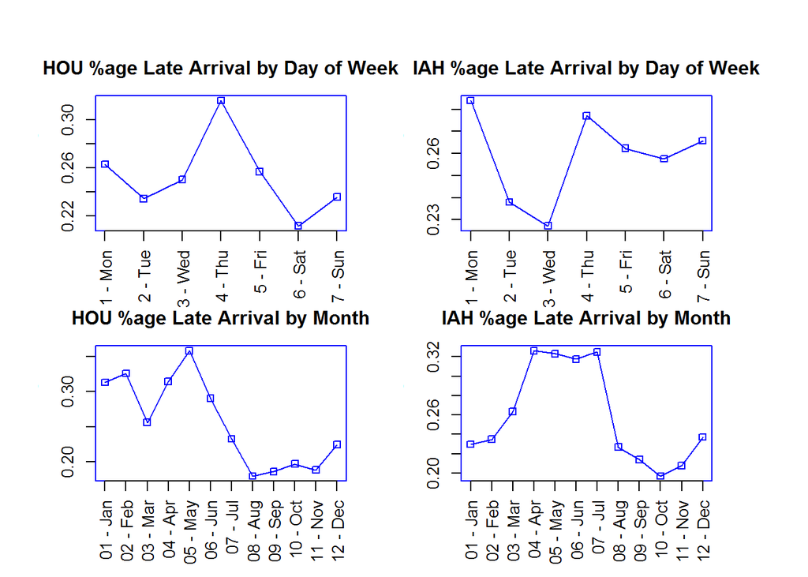

```r
par(mar=c(3, 3, 3, 3))
par(oma = c(2, 2, 2, 2))
par(pch=22, col="blue")
par(mfrow=c(2,2)) # all plots on one page
plot(perc_by_dow_hou$DayOfWeek, perc_by_dow_hou$ArrDelPerc, main="HOU %age Late Arrival by Day of Week", xaxt = 'n', ylab = "Percentage")
lines(perc_by_dow_hou$DayOfWeek, perc_by_dow_hou$ArrDelPerc, main="HOU %age Late Arrival by Day of Week", xaxt = 'n', ylab = "Percentage")
axis(1, at = perc_by_dow_hou$DayOfWeek, labels = perc_by_dow_hou$DayOfWeekLabel, las = 2)
plot(perc_by_dow_iah$DayOfWeek, perc_by_dow_iah$ArrDelPerc, main="IAH %age Late Arrival by Day of Week", xaxt = 'n', ylab = "Percentage")
lines(perc_by_dow_iah$DayOfWeek, perc_by_dow_iah$ArrDelPerc, main="IAH %age Late Arrival by Day of Week", xaxt = 'n', ylab = "Percentage")
axis(1, at = perc_by_dow_iah$DayOfWeek, labels = perc_by_dow_iah$DayOfWeekLabel, las = 2)
plot(perc_by_mth_hou$Month, perc_by_mth_hou$ArrDelPerc, main="HOU %age Late Arrival by Month", xaxt = 'n', ylab = "Percentage")
lines(perc_by_mth_hou$Month, perc_by_mth_hou$ArrDelPerc, main="HOU %age Late Arrival by Month", xaxt = 'n', ylab = "Percentage")
axis(1, at = perc_by_mth_hou$Month, labels = perc_by_mth_hou$MonthLabel, las = 2)
plot(perc_by_mth_iah$Month, perc_by_mth_iah$ArrDelPerc, main="IAH %age Late Arrival by Month", xaxt = 'n', ylab = "Percentage")
lines(perc_by_mth_iah$Month, perc_by_mth_iah$ArrDelPerc, main="IAH %age Late Arrival by Month", xaxt = 'n', ylab = "Percentage")
axis(1, at = perc_by_mth_iah$Month, labels = perc_by_mth_iah$MonthLabel, las = 2)
```

I don’t think these graphics call out any research possibilities, except perhaps an investigation into whether arrival delays occur more in April - June. A multi-year data set would be needed to research that.

The next graphic attempts to explore the “What’s the frequency for delayed flights by range of time delay?” question.

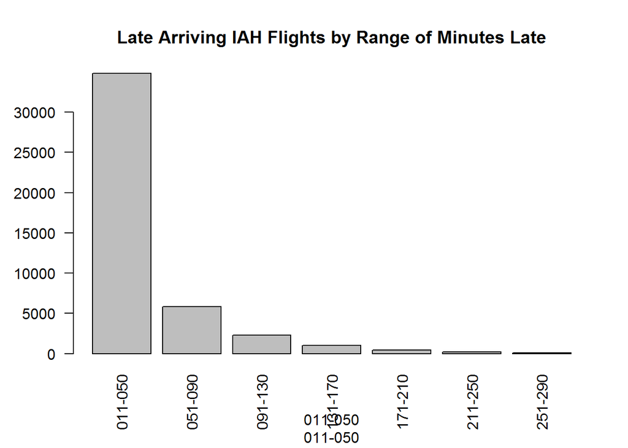

```r
s <- subset(hf_iah_final, ArrDelay_OverTen == 1)
x <- table(s$ArrDelay_Range)
barplot(x, main="Late Arriving IAH Flights by Range of Minutes Late", xlab = s$ArrDelay_Range, las = 2, legend.text = NULL)
```

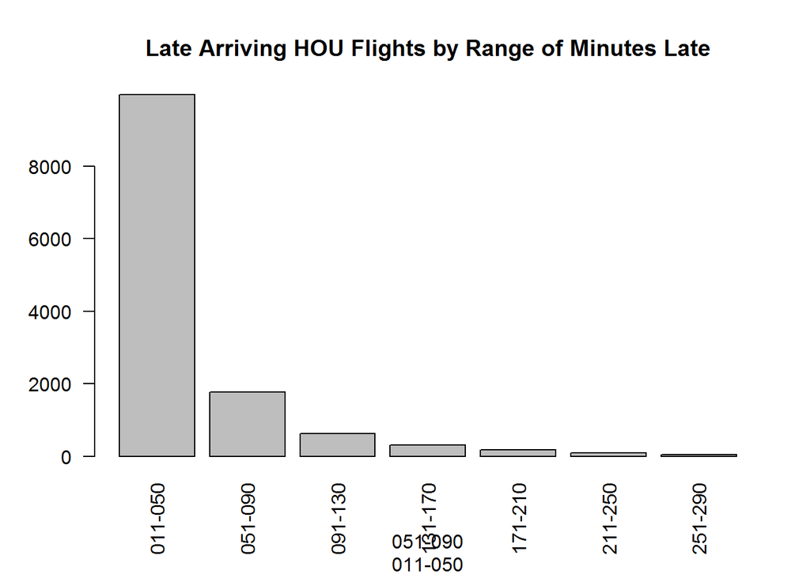

```r
s <- subset(hf_hou_final, ArrDelay_OverTen == 1)
x <- table(s$ArrDelay_Range)
barplot(x, main="Late Arriving HOU Flights by Range of Minutes Late", xlab = s$ArrDelay_Range, las = 2, legend.text = NULL)
```

I thought we might see a difference between HOU and IAH, but in fact both have similar distributions.

Finally, I installed Hadley Wickham’s ggplot2 package to create a scatterplot to explore the “Is there a relationship between the Distance of flights and the ArrDelay (for flights where ArrDelay > 10)?” question.

```r
# Load sqldf
install.packages("ggplot2", repos='https://mirrors.nics.utk.edu/cran/')
library(ggplot2)
```

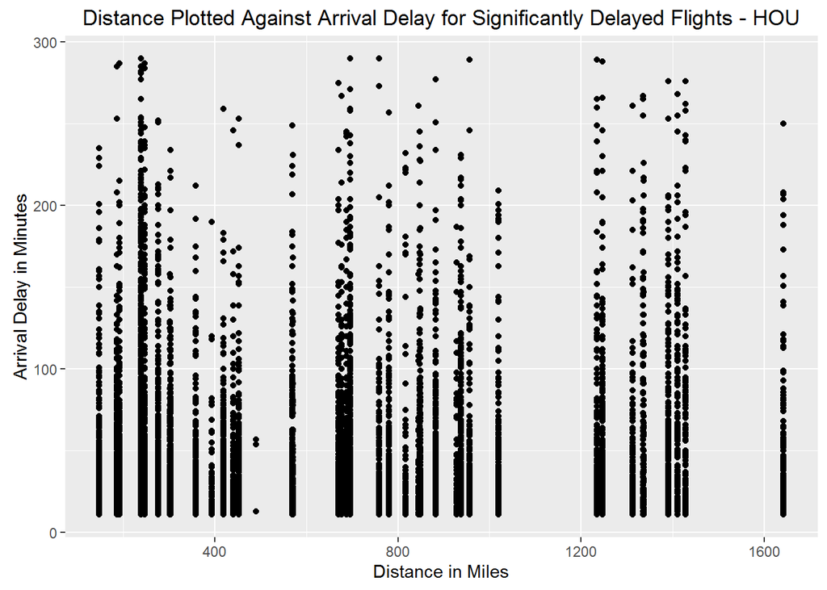

```r
s <- subset(hf_hou_final, ArrDelay_OverTen == 1)
ggplot(s, aes(x=s$Distance, y=s$ArrDelay)) + geom_point() + labs(title="Distance Plotted Against Arrival Delay for Significantly Delayed Flights - HOU",x="Distance in Miles", y = "Arrival Delay in Minutes")
```

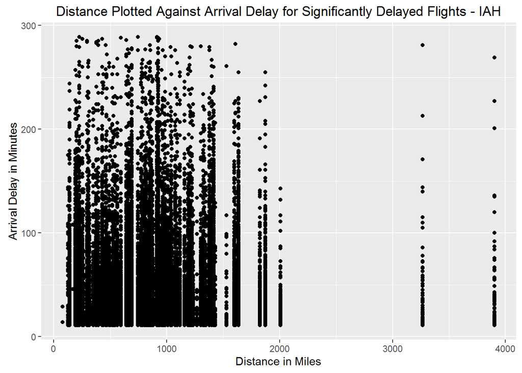

```r
s <- subset(hf_iah_final, ArrDelay_OverTen == 1)
ggplot(s, aes(x=s$Distance, y=s$ArrDelay)) + geom_point() + labs(title="Distance Plotted Against Arrival Delay for Significantly Delayed Flights - IAH",x="Distance in Miles", y = "Arrival Delay in Minutes")
```

Again, the graphics do not provide any insight to opportunities for additional analysis. It appears the distance of the flight is not related to the length of the arrival delay.